# statistical_analysis_epistasis

## Fold-Change Data

Here we look at the fold-change data used in the input files. This allows us to see positive and negative functional effects across the landscapes.

```r
fit_land = do.call("rbind", lapply(list.files(pattern="observed_values.csv", recursive = T), read_csv, skip = 1, show_col_types=F, col_names = c("id", "effect", "muts", "2", "3", "enz"))) %>% select(-c('2', '3'))

## Make fit_land have IDs by finding where muts are 0, i.e. start of new dataset, and multiplying
## Those values by the folder names to generate ID vector

fit_land_spots = c(which(fit_land$muts == 0), (dim(fit_land)[1] + 1)) # Add end of dataset
fit_land_counts = c()

for(i in 1:(length(fit_land_spots) - 1)) {

  if(i == 1) {
    fit_land_counts = c(fit_land_counts, fit_land_spots[i + 1] - 1)
  } else {
    fit_land_counts = c(fit_land_counts, fit_land_spots[i + 1] - fit_land_spots[i])
  }

}

## This assumes folders are read in the order that they are listed

fit_land_ids = rep(str_remove_all(list.files(pattern="observed_values.csv", recursive = T), "/observed_values.csv"), fit_land_counts)

fit_land$unique_id = fit_land_ids
```

The data shows the following distribution

```r
c(sum(fit_land$effect < log10(1/1.5)), sum(fit_land$effect >= log10(1/1.5) & fit_land$effect <= log10(1.5)), sum(fit_land$effect > log10(1.5)))
```

```
## [1] 343 415 746
```

### Histogram

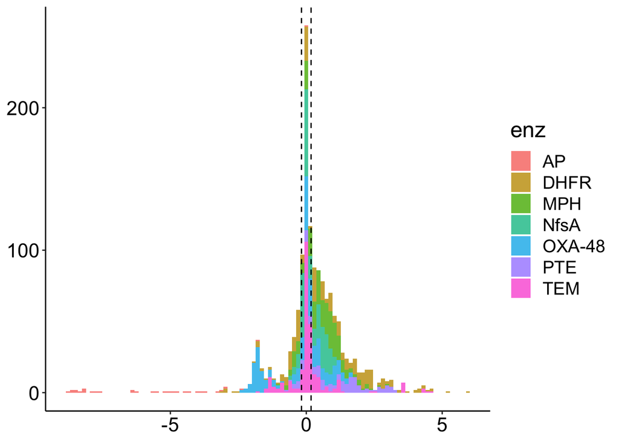

```r
fit_land %>%
  ggplot(aes(x = effect, fill = enz)) +
  geom_histogram(bins = 100, alpha = 0.8) +
  geom_vline(xintercept = log10(1.5), lty = 2) +
  geom_vline(xintercept = log10(1/1.5), lty = 2) +
  theme_classic() +
  theme(text = element_text(size=18), axis.text = element_text(size = 16, color = "black"),
        axis.title.y = element_blank(),
        axis.title.x = element_blank())
```

## Ratio Data

First we import the ratio datasets, which contains ratio values between predicted function based on the additive model vs observed function. These ratio values serve as a general metric for epistasis.

```r
all_ratios = do.call("rbind", lapply(list.files(pattern="ratio_export.csv", recursive = T), read_csv, skip = 1, show_col_types=F, col_names = c("id", "effect", "muts", "cv", "colors")))
```

Filtering ratio data to only include genotypes with 2+ mutations. Outputting length of vector.

```r
all_ratios = all_ratios %>% filter(muts > 1)

length(all_ratios$effect) # examined muts
```

```
## [1] 1245
```

Number and % of synergystic genotypes (i.e. ratio > 1.5-fold)

```r
sum(all_ratios$effect > 1.5) # synergystic
```

```
## [1] 484
```

```r
paste0("Synergystic ", round(sum(all_ratios$effect > 1.5)/length(all_ratios$effect)*100,2), "%", collapse = "") # synergystic %
```

```
## [1] "Synergystic 38.88%"
```

```r
sum(all_ratios$effect >= 1/1.5 & all_ratios$effect <= 1.5) # antagonistic
```

```
## [1] 428
```

```r
paste0("Neutral ", round(sum(all_ratios$effect >= 1/1.5 & all_ratios$effect <= 1.5)/length(all_ratios$effect)*100, 2), "%", collapse = "") # antagonistic %
```

```
## [1] "Neutral 34.38%"
```

```r
sum(all_ratios$effect < 1/1.5) # antagonistic
```

```
## [1] 333
```

```r
paste0("Antagonistic ", round(sum(all_ratios$effect < 1/1.5)/length(all_ratios$effect)*100, 2), "%", collapse = "") # antagonistic %
```

```
## [1] "Antagonistic 26.75%"
```

### Histogram

Shows distribution of positive and negative epistasis across the landscapes

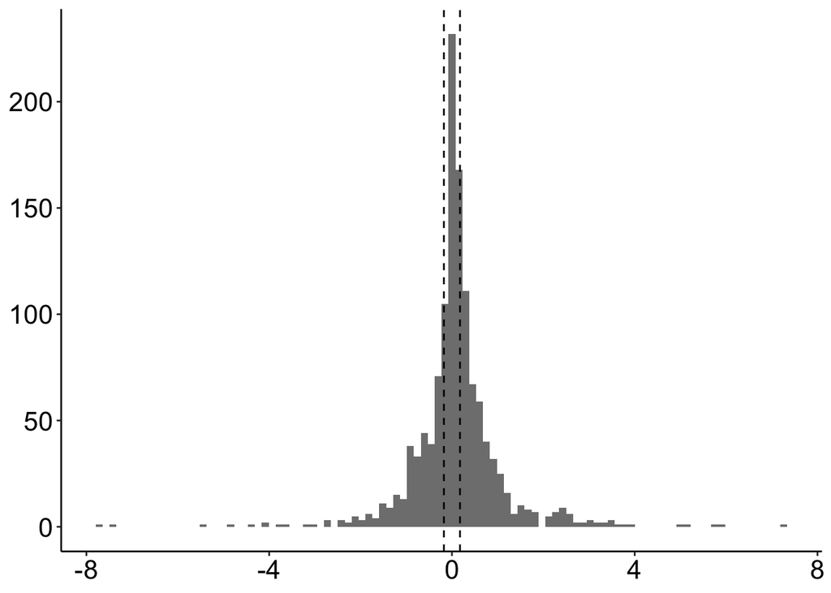

```r
all_ratios %>%
  ggplot(aes(x = log10(effect))) +
  geom_histogram(bins = 100, alpha = 0.8) +
  geom_vline(xintercept = log10(1.5), lty = 2) +
  geom_vline(xintercept = log10(1/1.5), lty = 2) +
  theme_classic() +
  theme(text = element_text(size=18), axis.text = element_text(size = 16, color = "black"),
        axis.title.y = element_blank(),
        axis.title.x = element_blank())
```

We can do the same thing for 2nd, 3rd, and 4th order

### 2nd order

```r
## 2nd step only

all_ratios_2 = all_ratios %>% filter(muts == 2)

length(all_ratios_2$effect) # examined muts
```

```
## [1] 419
```

```r
sum(all_ratios_2$effect > 1.5) # synergystic
```

```
## [1] 119
```

```r
paste0("Synergystic ", round(sum(all_ratios_2$effect > 1.5)/length(all_ratios_2$effect)*100, 2), "%", collapse = "") # synergystic %
```

```
## [1] "Synergystic 28.4%"
```

```r
sum(all_ratios_2$effect >= 1/1.5 & all_ratios_2$effect <= 1.5) # antagonistic
```

```
## [1] 198
```

```r
paste0("Neutral ", round(sum(all_ratios_2$effect >= 1/1.5 & all_ratios_2$effect <= 1.5)/length(all_ratios_2$effect)*100, 2), "%", collapse = "") # antagonistic %
```

```
## [1] "Neutral 47.26%"
```

```r
sum(all_ratios_2$effect < 1/1.5) # antagonistic
```

```
## [1] 102
```

```r
paste0("Antagonistic ", round(sum(all_ratios_2$effect < 1/1.5)/length(all_ratios_2$effect)*100, 2), "%", collapse = "") # antagonistic %
```

```
## [1] "Antagonistic 24.34%"
```

### 3rd order

```r
## 3rd step only

all_ratios_3 = all_ratios %>% filter(muts == 3)

length(all_ratios_3$effect) # examined muts
```

```
## [1] 438
```

```r
sum(all_ratios_3$effect > 1.5) # synergystic
```

```
## [1] 160
```

```r
paste0("Synergystic ", round(sum(all_ratios_3$effect > 1.5)/length(all_ratios_3$effect)*100, 2), "%", collapse = "") # synergystic %
```

```
## [1] "Synergystic 36.53%"
```

```r
sum(all_ratios_3$effect >= 1/1.5 & all_ratios_3$effect <= 1.5) # antagonistic
```

```
## [1] 129
```

```r
paste0("Neutral ", round(sum(all_ratios_3$effect >= 1/1.5 & all_ratios_3$effect <= 1.5)/length(all_ratios_3$effect)*100, 2), "%", collapse = "") # antagonistic %
```

```
## [1] "Neutral 29.45%"
```

```r
sum(all_ratios_3$effect < 1/1.5) # antagonistic
```

```
## [1] 149
```

```r
paste0("Antagonistic ", round(sum(all_ratios_3$effect < 1/1.5)/length(all_ratios_3$effect)*100, 2), "%", collapse = "") # antagonistic %
```

```
## [1] "Antagonistic 34.02%"
```

### 4th order

```r
## 4th step only

all_ratios_4 = all_ratios %>% filter(muts == 4)

length(all_ratios_4$effect) # examined muts
```

```
## [1] 267
```

```r
sum(all_ratios_4$effect > 1.5) # synergystic
```

```
## [1] 125
```

```r
paste0("Synergystic ", round(sum(all_ratios_4$effect > 1.5)/length(all_ratios_4$effect)*100, 2), "%", collapse = "") # synergystic %
```

```
## [1] "Synergystic 46.82%"
```

```r
sum(all_ratios_4$effect >= 1/1.5 & all_ratios_4$effect <= 1.5) # antagonistic
```

```
## [1] 74
```

```r
paste0("Neutral ", round(sum(all_ratios_4$effect >= 1/1.5 & all_ratios_4$effect <= 1.5)/length(all_ratios_4$effect)*100, 2), "%", collapse = "") # antagonistic %
```

```
## [1] "Neutral 27.72%"
```

```r
sum(all_ratios_4$effect < 1/1.5) # antagonistic
```

```
## [1] 68
```

```r
paste0("Antagonistic ", round(sum(all_ratios_4$effect < 1/1.5)/length(all_ratios_4$effect)*100, 2), "%", collapse = "") # antagonistic %
```

```
## [1] "Antagonistic 25.47%"
```

## Positional Functional Contribution Data

Here we import the functional contribution of single positions (not combinations), which resembles first order analysis across all datasets.

```r
## Reads all csvs in collated folder and combines them

d = do.call("rbind", lapply(list.files(pattern="*2d_box.csv", recursive = T), read_csv, show_col_types=F, col_names = c("positions", "identity", "mut", "effects", "enzyme", "type", "cond")))


d1 = d %>% filter_all(any_vars(!is.na(.))) # removes rows with all NA before making unique ID

d1 = d1 %>%
  unite("unique_id", c(positions, enzyme, type, cond), remove = F)
```

### Histogram

Spread of functional contributions of the positions. This shows whether introducing a mutation in a given position impacts the function positively or negatively (or neutral)

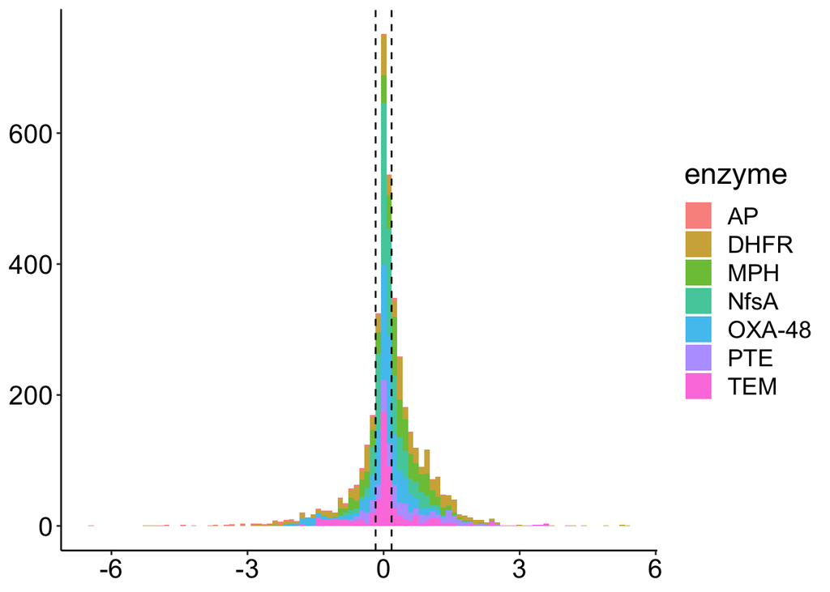

```r
d1 %>%
  ggplot(aes(x = effects, fill = enzyme)) +
  geom_histogram(bins = 100, alpha = 0.8) +
  geom_vline(xintercept = log10(1.5), lty = 2) +
  geom_vline(xintercept = log10(1/1.5), lty = 2) +
  theme_classic() +
  theme(text = element_text(size=18), axis.text = element_text(size = 16, color = "black"),
        axis.title.y = element_blank(),
        axis.title.x = element_blank())
```

Given this spread which percentage is significantly (using log10 1.5-fold cutoff) **negative**, **neutral**, and **positive** in that order

```r
general = c(sum(d1$effects < log10(1/1.5)) / length(d1$effects),
  sum(d1$effects <= log10(1.5) & d1$effects >= log10(1/1.5)) / length(d1$effects),
  sum(d1$effects > log10(1.5)) / length(d1$effects)
)

general
```

```
## [1] 0.1998031 0.3919783 0.4082185
```

## Heterogenity in Spread

Looks at 2*SD of each position/combination across all orders to determine functional heterogeneity.

This gives us a quick look at the general spread of heterogenity values and their mean.

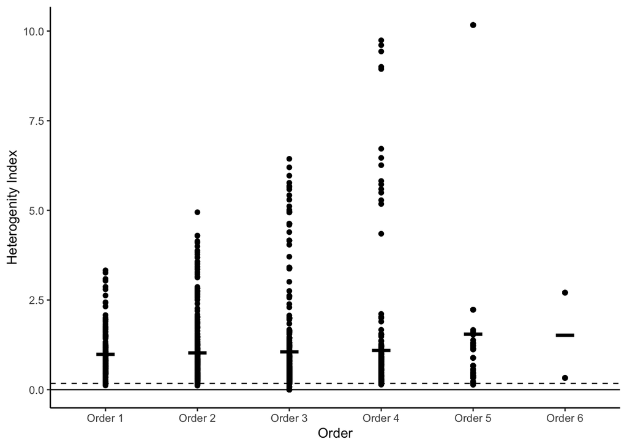

```r
idio_d = do.call("rbind", lapply(list.files(pattern="idio_df", recursive = T), read_csv, show_col_types=F))

idio_d %>%
  ggplot(aes(x = mutations, y = idiosync)) +
  geom_point() +
  geom_hline(yintercept = 0) +
  geom_hline(yintercept = log10(1.5), lty = 2) +
  stat_summary(fun=mean, colour="black", geom="crossbar", width=0.2) +
  labs(x = "Order", y = "Heterogenity Index") +
  theme_classic()
```

### Order 1

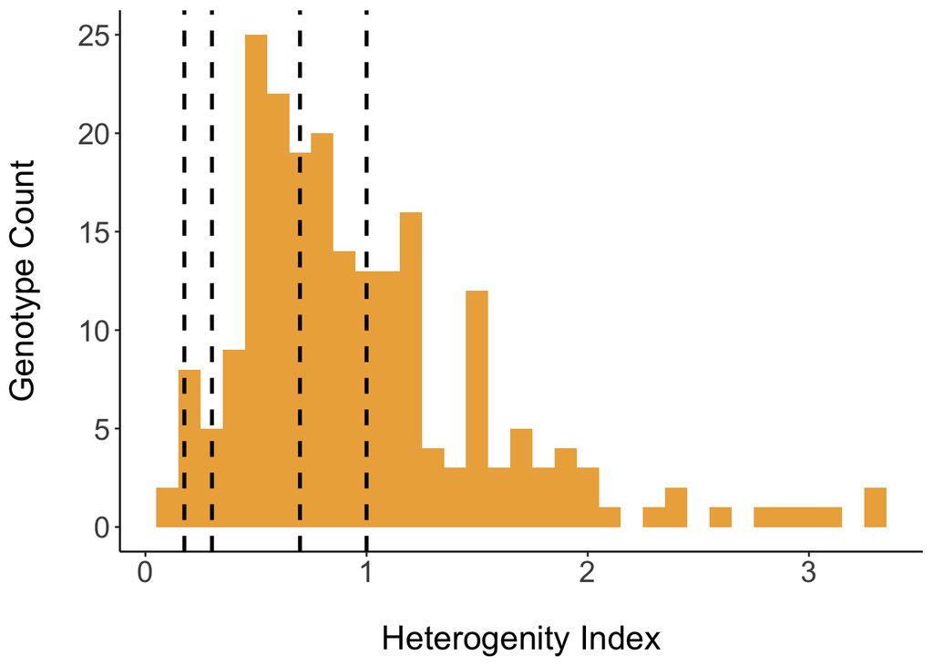

```r
idio_d %>%
  filter(mutations == "Order 1") %>%
  ggplot(aes(x = idiosync)) +
  geom_histogram(binwidth = 0.1, fill = "#edae49") +
  geom_vline(xintercept = log10(1.5), lty = 2, lwd = 1) +
  geom_vline(xintercept = log10(2), lty = 2, lwd = 1) +
  geom_vline(xintercept = log10(5), lty = 2, lwd = 1) +
  geom_vline(xintercept = log10(10), lty = 2, lwd = 1) +
  labs(x = "Heterogenity Index",
       y = "Genotype Count") +
  theme_classic() +
  theme(text = element_text(size=18), axis.text = element_text(size = 16),
        axis.title.y = element_text(margin = margin(t = 0, r = 20, b = 0, l = 0)),
        axis.title.x = element_text(margin = margin(t = 20, r = 0, b = 0, l = 0)))
```

First order positions which have a hetergenity index > log10 1.5-fold, 2-fold, 5-fold, and 10-fold

```r
idio_first = idio_d %>%
  filter(mutations == "Order 1") %>%
  pull(idiosync)

sum(idio_first > log10(1.5)) / length(idio_first)
```

```
## [1] 0.9813084
```

```r
sum(idio_first > log10(2)) / length(idio_first)
```

```
## [1] 0.9439252
```

```r
sum(idio_first > log10(5)) / length(idio_first)
```

```
## [1] 0.6168224
```

```r
sum(idio_first > log10(10)) / length(idio_first)
```

```
## [1] 0.3878505
```

### Order 2-4

Histogram to show heterogenity at Orders 2, 3, and 4 with the log10 1.5-fold significance threshold

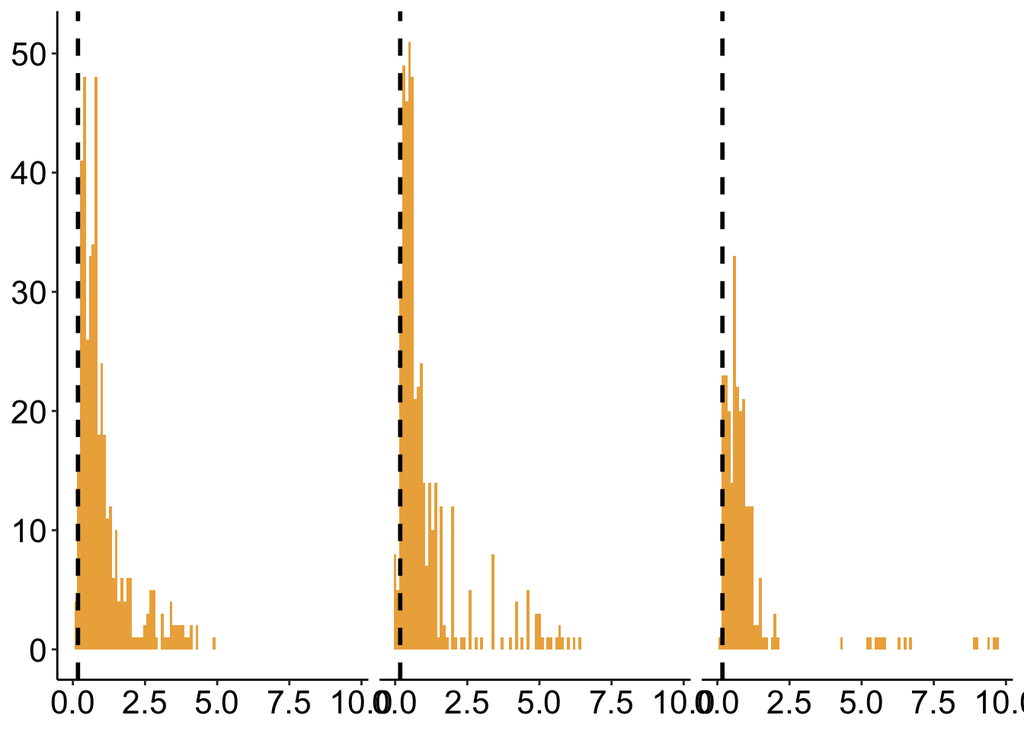

```r
idio_d %>%
  filter(mutations == "Order 2" | mutations == "Order 3" | mutations == "Order 4") %>%
  ggplot(aes(x = idiosync)) +
  geom_histogram(binwidth = 0.1, fill = "#edae49") +
  geom_vline(xintercept = log10(1.5), lty = 2, lwd = 1) +
  labs(x = "Idiosyncrasy Metric",
       y = "Genotype Count") +
  facet_wrap(~ mutations) +
  theme_classic() +
  theme(text = element_text(size=18), axis.text = element_text(size = 16, color = "black"),
        axis.title.y = element_blank(),
        axis.title.x = element_blank(),
        legend.position = "none",
        strip.background = element_blank(),
        strip.text.x = element_blank())
```

What percentage of positions remain significantly heterogeneous at these orders?

```r
idio_d %>%
  filter(mutations == "Order 2" | mutations == "Order 3" | mutations == "Order 4") %>%
  mutate(idiosync = idiosync > log10(1.5)) %>%
  group_by(mutations) %>%
  summarise(idiosync_sig = sum(idiosync),
            idiosync_total = length(idiosync),
            idiosync = sum(idiosync)/length(idiosync) * 100
            )
```

```
## # A tibble: 3 × 4
##   mutations idiosync_sig idiosync_total idiosync
##   <chr>            <int>          <int>    <dbl>
## 1 Order 2            412            419     98.3
## 2 Order 3            420            438     95.9
## 3 Order 4            240            245     98.0
```

## Heterogenity in Sign

Collects all $\Delta$$\Delta$Function data for all orders

```r
higher_order_list = list.files(pattern="higher_box", recursive = T)

higher_df = data.frame()
for(higher_file in 1:length(higher_order_list)){
  Condition = str_split(str_split(higher_order_list[higher_file], "_")[[1]][3], "/")[[1]][1]
  Measurement = str_split(higher_order_list[higher_file], "_")[[1]][2]
  Enzyme = str_split(higher_order_list[higher_file], "_")[[1]][1]
  appending_file = read_csv(higher_order_list[higher_file], show_col_types=F)
  appending_file$Condition = Condition
  appending_file$Measurement = Measurement
  appending_file$Enzyme = Enzyme
  higher_df = bind_rows(higher_df, appending_file)
}


higher_df = higher_df %>%
  unite("unique_id", c(pos, Condition, Measurement, Enzyme), remove = F)

higher_all_sign_check = higher_df %>%
  mutate(mutations = factor(paste("Order", mutations, sep = " "))) %>%
  group_by(unique_id, mutations) %>%
  summarise(min_effect = min(avg),
            max_effect = max(avg))
```

Assigning positive, neutral, negative, negative-neutral, positive-neutral, and negative-positive ‘types’ based on log10 1.5-fold threshold to every Order

```r
threshold = 1.5

types = c()
for(each in 1:dim(higher_all_sign_check)[1]){
  if(higher_all_sign_check$min_effect[each] < log10(1/threshold)){
    # Negative branch
    if(higher_all_sign_check$max_effect[each] < log10(1/threshold)) {
      # Full negative
      types = c(types, "Negative")
    } else if(higher_all_sign_check$max_effect[each] <= log10(threshold)) {
      # Negative Neutral
      types = c(types, "Neutral Negative")
    } else {
      # Negative Positive
      types = c(types, "Positive Negative")
    }
  } else {
    # Neutral or Positive
    if(higher_all_sign_check$min_effect[each] > log10(threshold)) {
      # Full positive
      types = c(types, "Positive")
    } else if(higher_all_sign_check$max_effect[each] > log10(threshold)) {
      # Neutral Positive
      types = c(types, "Neutral Positive")
    } else {
      # Neutral
      types = c(types, "Neutral")
    }
  }
}

higher_all_sign_check$type = factor(types)
```

All outputs show position/combination numbers in each catagory, followed by the total sum of all probed positions/combinations at that order, and finally percentages of each category

### Order 1

```r
order_checker = higher_all_sign_check %>%
  filter(mutations == "Order 1") %>%
  pull(type)

summary(order_checker)
```

```
##          Negative           Neutral  Neutral Negative  Neutral Positive
##                 2                 4                31                38
##          Positive Positive Negative
##                21               118
```

```r
sum(summary(order_checker))
```

```
## [1] 214
```

```r
summary(order_checker) / length(order_checker) * 100
```

```
##          Negative           Neutral  Neutral Negative  Neutral Positive
##         0.9345794         1.8691589        14.4859813        17.7570093
##          Positive Positive Negative
##         9.8130841        55.1401869
```

### Order 2

```r
order_checker = higher_all_sign_check %>%
  filter(mutations == "Order 2") %>%
  pull(type)

summary(order_checker)
```

```
##          Negative           Neutral  Neutral Negative  Neutral Positive
##                 4                 8                51                83
##          Positive Positive Negative
##                10               263
```

```r
sum(summary(order_checker))
```

```
## [1] 419
```

```r
summary(order_checker) / length(order_checker) * 100
```

```
##          Negative           Neutral  Neutral Negative  Neutral Positive
##         0.9546539         1.9093079        12.1718377        19.8090692
##          Positive Positive Negative
##         2.3866348        62.7684964
```

### Order 3

```r
order_checker = higher_all_sign_check %>%
  filter(mutations == "Order 3") %>%
  pull(type)

summary(order_checker)
```

```
##          Negative           Neutral  Neutral Negative  Neutral Positive
##                13                12                69                72
##          Positive Positive Negative
##                42               230
```

```r
sum(summary(order_checker))
```

```
## [1] 438
```

```r
summary(order_checker) / length(order_checker) * 100
```

```
##          Negative           Neutral  Neutral Negative  Neutral Positive
##          2.968037          2.739726         15.753425         16.438356
##          Positive Positive Negative
##          9.589041         52.511416
```

### Order 4

```r
order_checker = higher_all_sign_check %>%
  filter(mutations == "Order 4") %>%
  pull(type)

summary(order_checker)
```

```
##          Negative           Neutral  Neutral Negative  Neutral Positive
##                15                 8                50                42
##          Positive Positive Negative
##                25               127
```

```r
sum(summary(order_checker))
```

```
## [1] 267
```

```r
summary(order_checker) / length(order_checker) * 100
```

```
##          Negative           Neutral  Neutral Negative  Neutral Positive
##          5.617978          2.996255         18.726592         15.730337
##          Positive Positive Negative
##          9.363296         47.565543
```

## WT points to Mean Deviation

Purpose of this analysis was to determine the difference in $\Delta$$\Delta$Function between the WT-background contribution of a given position/combination and the mean contribution of a given position or combination

# Histogram

The spread of all positional contribution vs mean differences for each Order (1-4)

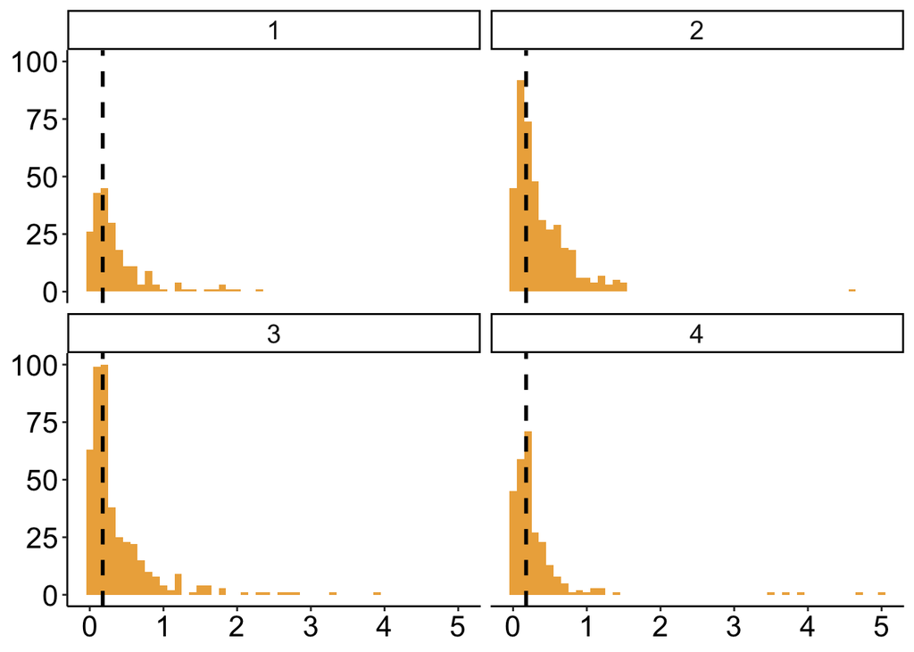

```r
higher_df_mean = higher_df %>%
  filter(mutations < 5) %>%
  group_by(unique_id) %>%
  summarise(avg = mean(avg))

devs = c()
cur_mutations = c()
for(i in 1:dim(higher_df_mean)[1]) {
  curr_id = higher_df_mean[i,1] %>% pull(unique_id)
  devs = c(devs, abs( (higher_df %>% filter(!str_detect(genotype, "1")) %>% filter(unique_id == curr_id) %>% pull(avg)) - (higher_df_mean[i,2] %>% pull(avg)) ))
  cur_mutations = c(cur_mutations, (higher_df %>% filter(!str_detect(genotype, "1")) %>% filter(unique_id == curr_id) %>% pull(mutations)))
}

devs_df_wt = data.frame(devs = devs, muts = cur_mutations)

## WT heterogenity for higher_orders

devs_df_wt %>%
  ggplot(aes(x = devs)) +
  geom_histogram(binwidth=0.1, fill = "#edae49") +
  geom_vline(xintercept = log10(1.5), lty = 2, lwd = 1) +
  facet_wrap(~ muts) +
  theme_classic() +
  theme(text = element_text(size=18), axis.text = element_text(size = 16, color = "black"),
        axis.title.y = element_blank(),
        axis.title.x = element_blank(),
        legend.position = "none")
```

Table to show percentages of WT-bg points that deviate from the positional/combinatorial mean by significance threshold (log10 1.5-fold)

```r
devs_df_wt %>%
  mutate(muts = factor(muts)) %>%
  group_by(muts) %>%
  summarise(percent = sum(devs > log10(1.5)) / length(devs),
            outlier = sum(devs > log10(1.5)),
            total = length(devs))
```

```
## # A tibble: 4 × 4
##   muts  percent outlier total
##   <fct>   <dbl>   <int> <int>
## 1 1       0.598     128   214
## 2 2       0.597     250   419
## 3 3       0.539     236   438
## 4 4       0.573     153   267
```

## All points to Mean Deviation

Purpose of this analysis was to determine the difference in $\Delta$$\Delta$Function between functional contribution of a given position/combination in any background and the mean contribution of a given position or combination

# Histogram

The spread of all positional contribution vs mean differences for each Order (1-4)

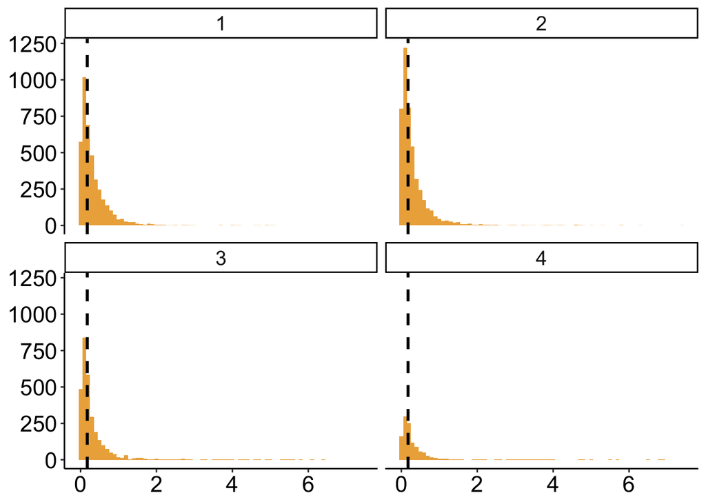

```r
higher_df_mean = higher_df %>%
  filter(mutations < 5) %>%
  group_by(unique_id) %>%
  summarise(avg = mean(avg))

devs = c()
cur_mutations = c()
for(i in 1:dim(higher_df_mean)[1]) {
  curr_id = higher_df_mean[i,1] %>% pull(unique_id)
  devs = c(devs, abs( (higher_df %>% filter(unique_id == curr_id) %>% pull(avg)) - (higher_df_mean[i,2] %>% pull(avg)) ))
  cur_mutations = c(cur_mutations, (higher_df %>% filter(unique_id == curr_id) %>% pull(mutations)))
}

devs_df = data.frame(devs = devs, muts = cur_mutations)

## All heterogenity for higher_orders

devs_df %>%
  ggplot(aes(x = devs)) +
  geom_histogram(binwidth=0.1, fill = "#edae49") +
  geom_vline(xintercept = log10(1.5), lty = 2, lwd = 1) +
  facet_wrap(~ muts) +
  theme_classic() +
  theme(text = element_text(size=18), axis.text = element_text(size = 16, color = "black"),
        axis.title.y = element_blank(),
        axis.title.x = element_blank(),
        legend.position = "none")
```

```r
devs_df %>%
  mutate(muts = factor(muts)) %>%
  group_by(muts) %>%
  summarise(percent = sum(devs > log10(1.5)) / length(devs),
            outlier = sum(devs > log10(1.5)),
            total = length(devs))
```

```
## # A tibble: 4 × 4
##   muts  percent outlier total
##   <fct>   <dbl>   <int> <int>
## 1 1       0.558    2267  4064
## 2 2       0.516    2412  4672
## 3 3       0.488    1451  2976
## 4 4       0.549     627  1142
```

# Individual Trends

This sections attempts to probe if the previous values from the statistical analysis are representative in the individual data sets

### Sign Heterogenity in Invididual datasets

```r
d_individual = d %>% filter_all(any_vars(!is.na(.))) # removes rows with all NA before making unique ID

d_individual = d_individual %>%
  unite("landscape_id", c(enzyme, type, cond), remove = F)

landscape_ids = unique(d_individual$landscape_id)

general_df = tibble()
for(i in 1:length(landscape_ids)) {
  d_curr_individual = d_individual %>% filter(landscape_id == landscape_ids[i])

  general = c(unique(d_curr_individual$enzyme),
    landscape_ids[i],
    sum(d_curr_individual$effects < log10(1/1.5)) / length(d_curr_individual$effects),
    sum(d_curr_individual$effects <= log10(1.5) & d_curr_individual$effects >= log10(1/1.5)) / length(d_curr_individual$effects),
    sum(d_curr_individual$effects > log10(1.5)) / length(d_curr_individual$effects)
  )

  general_df = rbind(general_df, general)
}

colnames(general_df) = c("Enzyme", "Landscape ID", "Negative", "Neutral", "Positive")

general_df[-1]
```

```
##            Landscape ID           Negative           Neutral          Positive
## 1            AP_catef_1              0.775             0.075              0.15
## 2         DHFR_ic50_c57              0.375           0.09375           0.53125
## 3         DHFR_ic50_c58              0.375           0.09375           0.53125
## 4         DHFR_ic50_c59            0.46875           0.15625             0.375
## 5         DHFR_ic50_c60              0.375           0.21875           0.40625
## 6         DHFR_ic50_c61              0.125            0.3125            0.5625
## 7      DHFR_ic75_palmer  0.223958333333333              0.25 0.526041666666667
## 8       DHFR_kcat_trajg             0.6625               0.2            0.1375
## 9       DHFR_kcat_trajr             0.5875            0.2875             0.125
## 10        DHFR_ki_trajg                  0                 0                 1
## 11        DHFR_ki_trajr                  0                 0                 1
## 12     MPH_catact_CaPTM               0.15            0.1875            0.6625
## 13     MPH_catact_CdPTM             0.1375            0.3375             0.525
## 14     MPH_catact_CoPTM                0.2            0.0875            0.7125
```

[output cut: 31 more lines]

For example, AP shows very negative contribution at 77.5% of all mutations, DHFR kcats are predominantly negative while Kis are almost all positive (due to the adaptive nature of the mutations). MPH shows strong positives as it is also adaptive. NfsA is predominantly neutral, with some positive contribution. OXA is positive and neutral for adaptive trajectories, and negative and neutral for trade-off. PTE is positive for its adaptive substrate, but shows more negative behavior for lactones and OPs. TEM across all antibiotics is predominantly neutral (no directy adaptation). Finally the adaptive MIC of TEM is mostly positive with 66.3%.

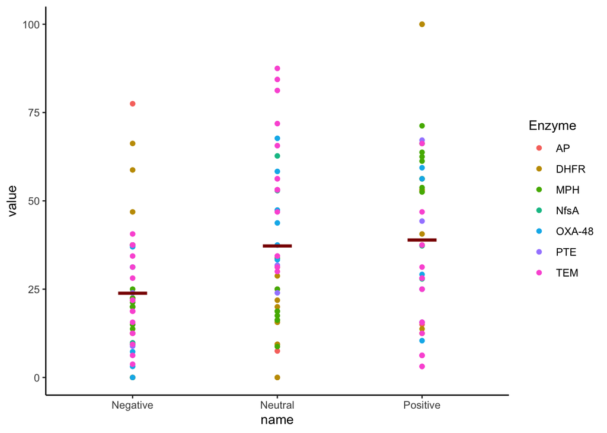

```r
general_df %>%
  pivot_longer(c(3,4,5)) %>%
  mutate(value = as.numeric(value)*100) %>%
  ggplot(aes(x = name, y = value, color = Enzyme)) +
  geom_point() +
  stat_summary(fun=mean, colour="darkred", geom="crossbar", width=0.2) +
  theme_classic()
```

### Still need to implement individual representation of functional heterogeneity and deviation from WT

# Prediction

Leaving this section for the MAE prediction part

# Trajectory

### Seeing how adaptive trajectories are affected by epistasis

First I need to create a global trajectory data frame

```r
all_traj = do.call("rbind", lapply(list.files(pattern="traj_epi_*", recursive = T), read_csv, skip = 1, show_col_types=F, col_names = c("genotype", "avg", "pos", "mutations", "likely", "enzyme_name", "measure_type", "cond")))

all_traj = all_traj %>% unite("unique_id", c(enzyme_name, measure_type, cond), remove = F)
```

Next I need to decide which landscapes are adaptive. These are listed below:

```r
adaptive_trajectories = c("DHFR_ki_trajg",
                          "DHFR_ki_trajr",
                          "MPH_catact_ZnPTM",
                          "NfsA_ec50_2039",
                          "NfsA_ec50_3637",
                          "OXA-48_ic50_CAZtraj1",
                          "OXA-48_ic50_CAZtraj2",
                          "OXA-48_ic50_CAZtraj3",
                          "PTE_catact_2NH",
                          "TEM_MIC_weinreich",
                          "DHFR_ic75_palmer")

adaptive_traj = all_traj %>% filter(unique_id %in% adaptive_trajectories)
```

Which genotypes in the adaptive landscapes for the favored trajectory are POSITIVELY epistatic and epistatic in general

Note: some trajectories don’t go to the last variant, so we explore epistasis of all other genotypes which may go beyond last variant

```r
adaptive_traj_favored = adaptive_traj %>% filter(mutations > 1 & likely) %>% pull(avg)

sum(adaptive_traj_favored > log10(1.5)) / length(adaptive_traj_favored)
```

```
## [1] 0.3809524
```

```r
sum(adaptive_traj_favored > log10(1.5) | adaptive_traj_favored < log10(1/1.5)) / length(adaptive_traj_favored)
```

```
## [1] 0.6428571
```

How many positive epistatic vs all epistatic genotypes vs all genotypes encountered in these landscapes?

```r
sum(adaptive_traj_favored > log10(1.5))
```

```
## [1] 16
```

```r
sum(adaptive_traj_favored > log10(1.5) | adaptive_traj_favored < log10(1/1.5))
```

```
## [1] 27
```

```r
length(adaptive_traj_favored)
```

```
## [1] 42
```

```r
`%notin%` <- Negate(`%in%`)

non_adaptive_traj_favored = all_traj %>% filter(unique_id %notin% adaptive_trajectories & mutations > 1 & !likely) %>% pull(avg)

sum(non_adaptive_traj_favored < log10(1/1.5))
```

```
## [1] 191
```

```r
sum(non_adaptive_traj_favored > log10(1.5) | non_adaptive_traj_favored < log10(1/1.5))
```

```
## [1] 389
```

```r
length(non_adaptive_traj_favored)
```

```
## [1] 583
```

```r
sum(non_adaptive_traj_favored < log10(1/1.5)) / length(non_adaptive_traj_favored)
```

```
## [1] 0.3276158
```

```r
sum(non_adaptive_traj_favored > log10(1.5) | non_adaptive_traj_favored < log10(1/1.5)) / length(non_adaptive_traj_favored)
```

```
## [1] 0.6672384
```

### Prediction of relevant trajectories

```r
adaptive_traj_fave = adaptive_traj %>% filter(likely)

###

plotting_d = tibble()
dummy2 = data.frame()

for(i in 1:length(adaptive_trajectories)) {

  suffix = tail(str_split(adaptive_trajectories[i], "_")[[1]], 1)

  file = paste0("pred_df_", suffix, "_", adaptive_trajectories[i], ".csv")

  d = read_csv(paste0(adaptive_trajectories[i], "/", file), show_col_types=F)

  genos = str_replace_all(adaptive_traj_fave[which(adaptive_traj_fave$unique_id %in% adaptive_trajectories[i]),]$genotype, "x", "1")

  genos = c(str_replace_all(genos[1], "1", "0"), genos)

  dummy2 = rbind(dummy2, data.frame(trajectory = adaptive_trajectories[i], Z = d[which(d$numbers == tail(genos, 1)),]$`observed effect`))

  others = c()
  for(j in 1:(length(genos) - 2)) {
    others = c(others, colnames(d)[which(colnames(d) == "mutations") + j]) ## Get all steps before final step of evaluated genotype
  }

  plotting_d = rbind(plotting_d, d[which(d$numbers %in% genos),] %>%
    pivot_longer(cols = c(`observed effect`,
                          `epistatic effect`,
                          `WT effect`,
                          others)) %>% ## add those steps into line plots
    select(c(mutations, name, value)) %>%
    mutate(trajectory = adaptive_trajectories[i]))

}
```

Next we plot all of those

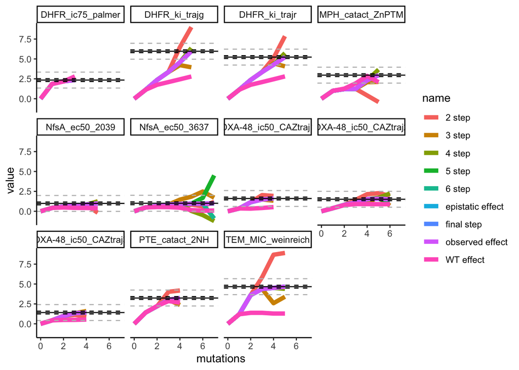

```r
ggplot(plotting_d, aes(x = mutations, y = value, color = name)) +
  geom_line(lwd = 2) +
  facet_wrap(~ trajectory) +
  geom_hline(data = dummy2, aes(yintercept = Z)) +
  geom_hline(data = dummy2, aes(yintercept = Z + log10(1.5)), lty = 2) +
  geom_hline(data = dummy2, aes(yintercept = Z - log10(1.5)), lty = 2) +
  geom_hline(data = dummy2, aes(yintercept = Z + log10(10)), lty = 2, color = "grey") +
  geom_hline(data = dummy2, aes(yintercept = Z - log10(10)), lty = 2, color = "grey") +
  theme_classic()
```

Also return as a table

```r
plotting_d %>%
  pivot_wider(names_from = name, values_from = value)
```

```
## # A tibble: 64 × 11
##    mutations trajectory  `observed effect` `epistatic effe… `WT effect` `2 step`
##        <dbl> <chr>                   <dbl>            <dbl>       <dbl>    <dbl>
##  1         0 DHFR_ki_tr…              0             -0.0124        0        0
##  2         1 DHFR_ki_tr…              1.13           1.14          1.13     1.13
##  3         2 DHFR_ki_tr…              2.36           2.35          1.75     2.36
##  4         3 DHFR_ki_tr…              3.35           3.37          2.09     3.38
##  5         4 DHFR_ki_tr…              4.58           4.57          2.44     6.48
##  6         5 DHFR_ki_tr…              5.97           5.98          2.79     9.00
##  7         0 DHFR_ki_tr…              0             -0.0155        0        0
##  8         1 DHFR_ki_tr…              1.13           1.15          1.13     1.13
##  9         2 DHFR_ki_tr…              2.36           2.35          1.75     2.36
## 10         3 DHFR_ki_tr…              3.35           3.37          2.09     3.38
## # … with 54 more rows, and 5 more variables: 3 step <dbl>, 4 step <dbl>,
## #   final step <dbl>, 5 step <dbl>, 6 step <dbl>
```

```r
write.csv(plotting_d %>%
  pivot_wider(names_from = name, values_from = value) , "/Users/karolbuda/OneDrive - UBC/PhD/Epistasis_Lit/Bulk/preds.csv")
```

### Ruggedness plots

I can make a ruggedness plot for each adaptive landscape, where deviation from 0 implies epistatic contribution of that genotype

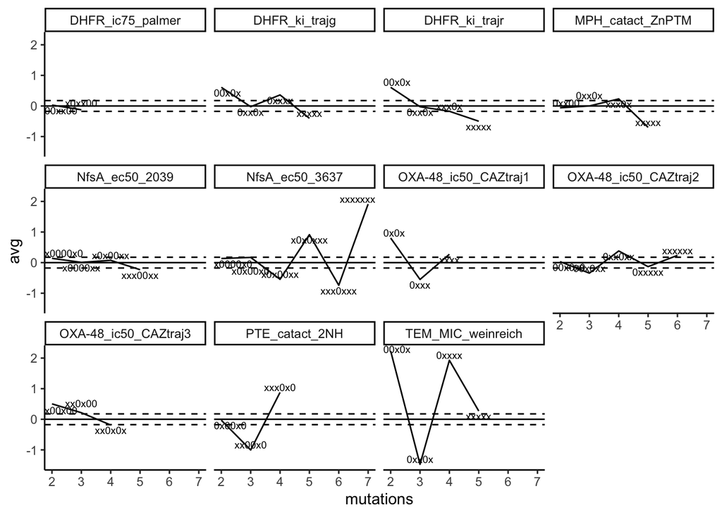

```r
adaptive_traj %>%
  filter(mutations > 1 & likely) %>%
  ggplot(aes(x = mutations, y = avg)) +
  geom_line() +
  geom_text_repel(aes(label = genotype), force = 1.5, direction = "y", box.padding = 0, segment.size = 0.2, size = 2.5) +
  geom_hline(yintercept = log10(1.5), lty = 2) +
  geom_hline(yintercept = log10(1/1.5), lty = 2) +
  geom_hline(yintercept = 0) +
  facet_wrap(~ unique_id) +
  theme_classic()
```

What if we compare it to the mean at that combination or position as well, not just assumed additivity (0 +/- log10(1.5))?

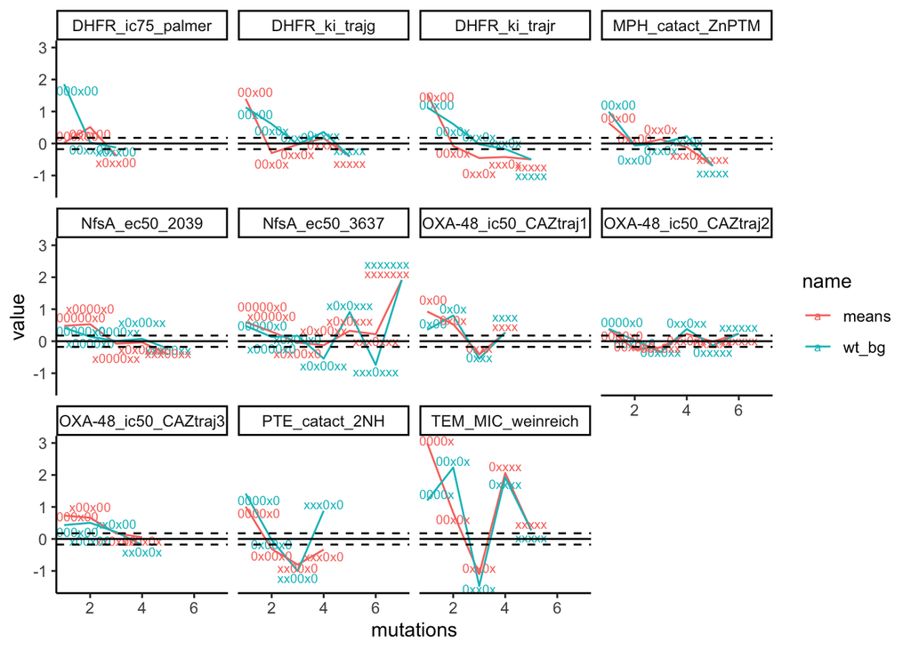

```r
higher_means = higher_df %>%
  unite("partial_id", c(Enzyme, Measurement, Condition), remove = F) %>%
  filter(partial_id %in% adaptive_trajectories) %>% ## use partial ID to only pick up the adaptive trajectories
  group_by(unique_id) %>%
  mutate(avg = mean(avg)) %>% ## Is arithmetic mean OK here?
  ungroup() %>%
  distinct(unique_id, .keep_all = T) ## Remove unique_id replicates

adaptive_means = higher_means %>% arrange(partial_id, pos) %>% pull(avg)

adaptive_traj = adaptive_traj %>% arrange(unique_id, pos) %>% mutate(means = adaptive_means)

adaptive_traj %>%
  filter(likely) %>%
  mutate(wt_bg = avg) %>%
  pivot_longer(c(wt_bg, means)) %>%
  ggplot(aes(x = mutations, y = value, color = name)) +
  geom_line() +
  geom_text_repel(aes(label = genotype), force = 1.5, direction = "y", box.padding = 0, segment.size = 0.2, size = 2.5) +
  geom_hline(yintercept = log10(1.5), lty = 2) +
  geom_hline(yintercept = log10(1/1.5), lty = 2) +
  geom_hline(yintercept = 0) +
  facet_wrap(~ unique_id) +
  theme_classic()
```

Which one of the genotypes seen above are the outliers?

```r
adaptive_traj %>%
  mutate(outlier = abs(means - avg) > log10(1.5))
```

```
## # A tibble: 645 × 11
##    genotype     avg pos      mutations likely unique_id enzyme_name measure_type
##    <chr>      <dbl> <chr>        <dbl> <lgl>  <chr>     <chr>       <chr>
##  1 x00000    0.643  p1               1 FALSE  DHFR_ic7… DHFR        ic75
##  2 xx0000    0.0120 p1|p21           2 FALSE  DHFR_ic7… DHFR        ic75
##  3 xxx000    4.09   p1|p21|…         3 FALSE  DHFR_ic7… DHFR        ic75
##  4 xxxx00   -3.44   p1|p21|…         4 FALSE  DHFR_ic7… DHFR        ic75
##  5 xxxxx0    0.213  p1|p21|…         5 FALSE  DHFR_ic7… DHFR        ic75
##  6 xxxxxx   -7.19   p1|p21|…         6 FALSE  DHFR_ic7… DHFR        ic75
##  7 xxxx0x   10.4    p1|p21|…         5 FALSE  DHFR_ic7… DHFR        ic75
##  8 xxx0x0   -3.82   p1|p21|…         4 FALSE  DHFR_ic7… DHFR        ic75
##  9 xxx0xx    2.58   p1|p21|…         5 FALSE  DHFR_ic7… DHFR        ic75
## 10 xxx00x   -5.30   p1|p21|…         4 FALSE  DHFR_ic7… DHFR        ic75
## # … with 635 more rows, and 3 more variables: cond <chr>, means <dbl>,
## #   outlier <lgl>
```

What % of adaptive landscape genotypes are outliers from the mean? What % of adaptive accessible trajectory genotypes are outliers from the mean? What % of adaptive less accessible trajectory genotypes are outliers from the mean?

```r
adaptive_traj_final = adaptive_traj %>%
  mutate(outlier = abs(means - avg) > log10(1.5))

length(adaptive_traj_final$outlier)
```

```
## [1] 645
```

```r
sum(adaptive_traj_final$outlier)
```

```
## [1] 309
```

```r
sum(adaptive_traj_final$outlier) / length(adaptive_traj_final$outlier)
```

```
## [1] 0.4790698
```

```r
length(filter(adaptive_traj_final, likely) %>% pull(outlier))
```

```
## [1] 53
```

```r
sum(filter(adaptive_traj_final, likely) %>% pull(outlier))
```

```
## [1] 30
```

```r
sum(filter(adaptive_traj_final, likely) %>% pull(outlier)) / length(filter(adaptive_traj_final, likely) %>% pull(outlier))
```

```
## [1] 0.5660377
```

```r
length(filter(adaptive_traj_final, !likely) %>% pull(outlier))
```

```
## [1] 592
```

```r
sum(filter(adaptive_traj_final, !likely) %>% pull(outlier))
```

```
## [1] 279
```

```r
sum(filter(adaptive_traj_final, !likely) %>% pull(outlier)) / length(filter(adaptive_traj_final, !likely) %>% pull(outlier))
```

```
## [1] 0.4712838
```

# Diminishing Returns

Next we try to see if adaptive vs random trajectories show diminishing returns.

Doing for single mutants first for every single landscape…

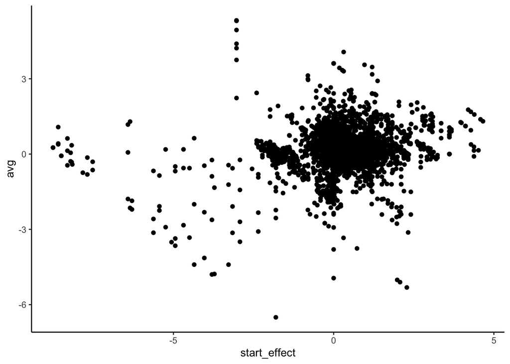

```r
higher_df_diminish = higher_df %>%
  unite("partial_id", c(Enzyme, Measurement, Condition)) %>%
  filter(mutations == 1) %>%
  mutate(from = str_replace_all(genotype, "x", "0"),
         to = str_replace_all(genotype, "x", "1"))

start_effect = c()
for(i in 1:dim(higher_df_diminish)[1]) {
  start_effect = c(start_effect, filter(fit_land, unique_id == higher_df_diminish$partial_id[i] & id == higher_df_diminish$from[i])
  %>% pull(effect))
}

higher_df_diminish$start_effect = start_effect

ggplot(higher_df_diminish, aes(x = start_effect, y = avg)) +
  geom_point() +
  theme_classic()
```

Next only looking at adaptive landscapes

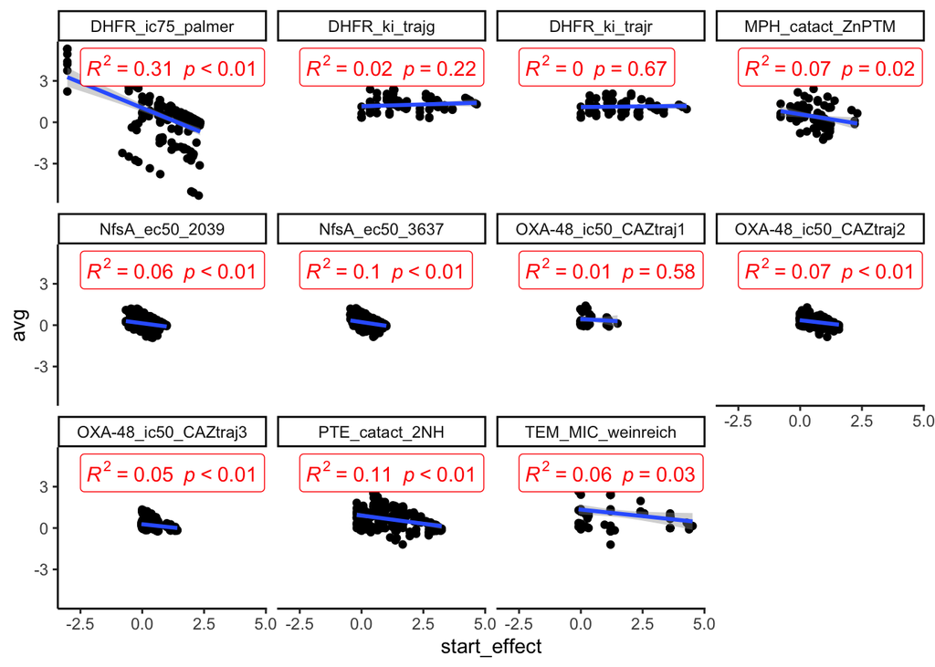

```r
higher_df_diminish = higher_df %>%
  unite("partial_id", c(Enzyme, Measurement, Condition)) %>%
  filter(mutations == 1) %>%
  mutate(from = str_replace_all(genotype, "x", "0"),
         to = str_replace_all(genotype, "x", "1")) %>%
  filter(partial_id %in% adaptive_trajectories)

start_effect = c()
for(i in 1:dim(higher_df_diminish)[1]) {
  start_effect = c(start_effect, filter(fit_land, unique_id == higher_df_diminish$partial_id[i] & id == higher_df_diminish$from[i])
  %>% pull(effect))
}

higher_df_diminish$start_effect = start_effect

ggplot(higher_df_diminish, aes(x = start_effect, y = avg)) +
  geom_point() +
  facet_wrap(~ partial_id) +
  geom_smooth(method = 'lm', formula = y ~ x) +
  stat_cor(aes(label = paste(..rr.label.., ..p.label.., sep = "~~")), color = "red", geom = "label", label.x = -2.5, label.y = 4, r.accuracy = 0.01, p.accuracy = 0.01) +
  theme_classic()
```

What about only looking at the best step from each starting point?

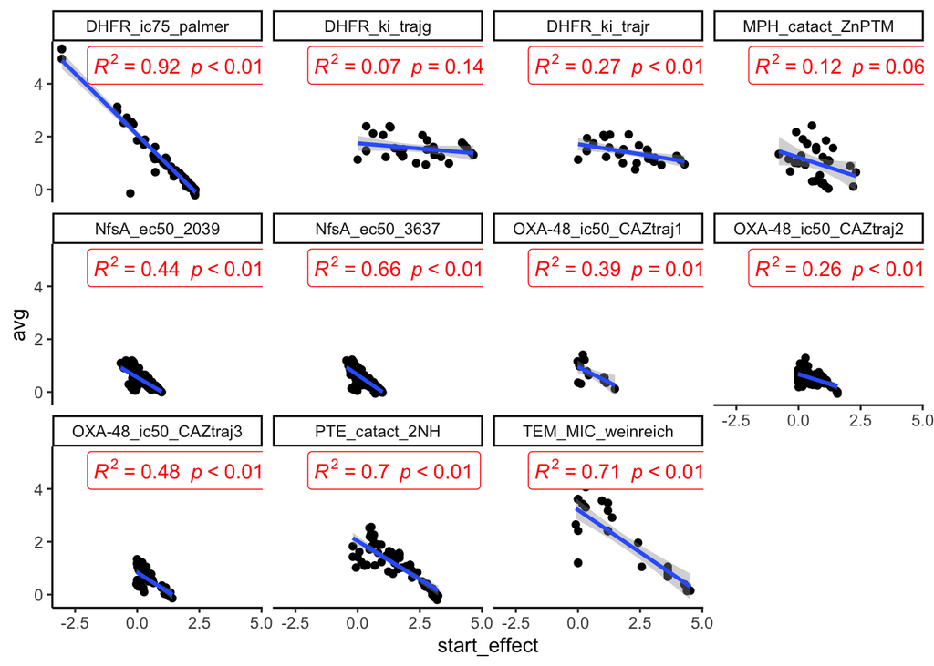

```r
higher_df_diminish %>%
  group_by(partial_id, from) %>%
  summarise(avg = max(avg), start_effect = start_effect) %>%
  distinct() %>%
  ggplot(aes(x = start_effect, y = avg)) +
  geom_point() +
  geom_smooth(method = 'lm', formula = y ~ x) +
  stat_cor(aes(label = paste(..rr.label.., ..p.label.., sep = "~~")), color = "red", geom = "label", label.x = -2, label.y = 4.7, r.accuracy = 0.01, p.accuracy = 0.01) +
  facet_wrap(~ partial_id) +
  theme_classic()
```

What about only looking at the adaptive trajectories?

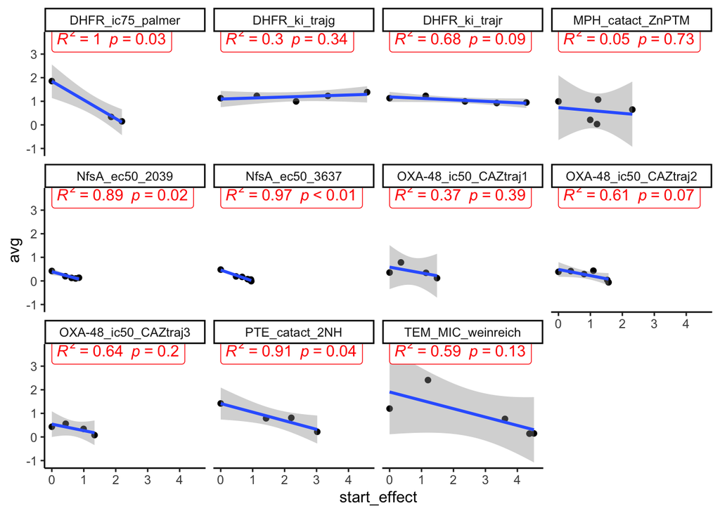

```r
all_traj_points = all_traj %>%
  filter(likely & unique_id %in% adaptive_trajectories) %>%
  mutate(genotype = str_replace_all(genotype, "x", "1")) %>%
  select(genotype, unique_id)


higher_df_diminish_traj = tibble()
prev_geno = c()
for(i in 1:dim(all_traj_points)[1]) {

  if(length(prev_geno) > 0) {
    higher_df_diminish_traj = rbind(higher_df_diminish_traj, higher_df_diminish %>% filter(partial_id == all_traj_points$unique_id[i] & to == all_traj_points$genotype[i]) %>% filter(from == prev_geno))
  } else {
    higher_df_diminish_traj = rbind(higher_df_diminish_traj, higher_df_diminish %>% filter(partial_id == all_traj_points$unique_id[i] & to == all_traj_points$genotype[i]))
  }

  if(i != dim(all_traj_points)[1]) {
    if(all_traj_points$unique_id[i + 1] == all_traj_points$unique_id[i]) {
      prev_geno = tail(higher_df_diminish_traj$to, 1)
    } else {
      prev_geno = c()
    }
  }

}

higher_df_diminish_traj %>%
  ggplot(aes(x = start_effect, y = avg)) +
  geom_point() +
  geom_smooth(method = 'lm', formula = y ~ x) +
  stat_cor(aes(label = paste(..rr.label.., ..p.label.., sep = "~~")), color = "red", geom = "label", label.x = 0, label.y = 3.7, r.accuracy = 0.01, p.accuracy = 0.01) +
  facet_wrap(~ partial_id) +
  theme_classic()
```